# Machine Learn Project

November 20, 2015

# Data Processing

First step in data processing part is to is to load all the library we are going to need plus the training and test set data. Albeit not properly consistent with the principle of reproducibility we assume that the data has been already loaded in the work directory that the user is going to use.

```r
set.seed(1234)
library(caret)
library(randomForest)
library(rattle)
library(rpart)
Traing<-read.csv("pml-training.csv",sep=",",header=T,na.strings=c("NA",""))
Tst<-read.csv("pml-testing.csv",sep=",",header=T,na.strings=c("NA",""))
```

```r
Vr0<-nearZeroVar(Traing,saveMetrics = TRUE)
Tg<-Traing[,-Vr0$nzv]

for (i in ncol(Tg):1){
 if (sum( is.na( Tg[, i] ) ) /nrow(Tg) >= 0.6){
   Tg<-Tg[,-i]
 }
}
Tg<-Tg[,-(1:5)]
```

The next step is to proceed with taking a subsample of the training data that we will use for *cross validation*.

```r
cvcreat<- createDataPartition(Tg$classe, p=0.60, list=FALSE)
tring<- Tg[cvcreat,]
cvlid<- Tg[-cvcreat,]
```

# Model selection

As we have seen during the course, *Random Forest* is one of the most accurate algorithms in town. In this case we will try to understand which is the most accurate between this method and the *Decision Tree*.

## Decision Tree

Now let’s try on our training data this algorithm using caret library

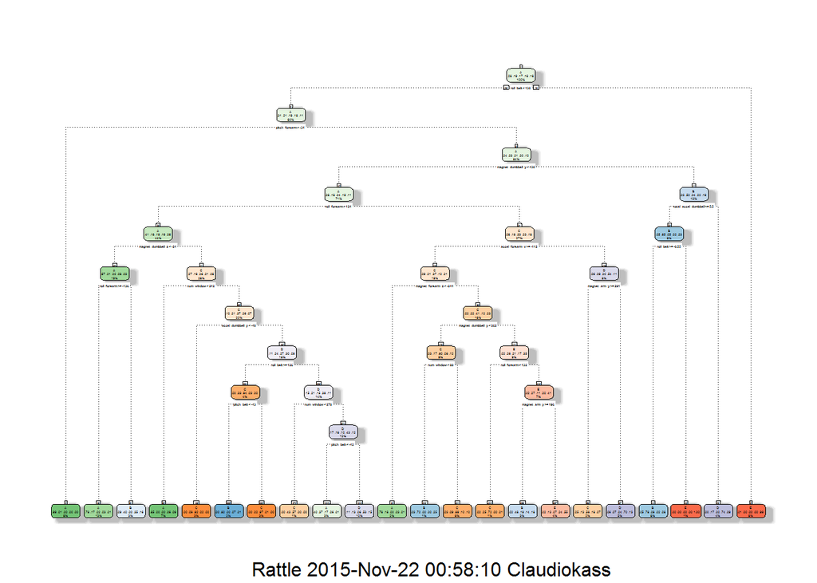

```r
modFit <- rpart(classe ~ ., method="class",data=tring)
fancyRpartPlot(modFit)
```

now we try to test this model to the validation test and then we use the Confusion matrix to understand the accuracy of this model.

```r
fcst<-predict(modFit, cvlid, type = "class")
confusionMatrix(fcst, cvlid$classe)
```

```
## Confusion Matrix and Statistics
##
##           Reference
## Prediction    A    B    C    D    E
##          A 2014  269   70   97   66
##          B   77  864  107  121  156
##          C   20  186 1062  103   61
##          D  116  152  100  889  196
##          E    5   47   29   76  963
##
## Overall Statistics
##
##                Accuracy : 0.7382
##                  95% CI : (0.7283, 0.7479)
##     No Information Rate : 0.2845
##     P-Value [Acc > NIR] : < 2.2e-16
##
##                   Kappa : 0.6676
##  Mcnemar's Test P-Value : < 2.2e-16
##
## Statistics by Class:
##
##                      Class: A Class: B Class: C Class: D Class: E
## Sensitivity            0.9023   0.5692   0.7763   0.6913   0.6678
## Specificity            0.9106   0.9271   0.9429   0.9140   0.9755
## Pos Pred Value         0.8005   0.6521   0.7416   0.6118   0.8598
## Neg Pred Value         0.9591   0.8997   0.9523   0.9379   0.9288
## Prevalence             0.2845   0.1935   0.1744   0.1639   0.1838
## Detection Rate         0.2567   0.1101   0.1354   0.1133   0.1227
## Detection Prevalence   0.3207   0.1689   0.1825   0.1852   0.1427
## Balanced Accuracy      0.9065   0.7482   0.8596   0.8027   0.8217
```

as we can see the accuracy of this algorithm does not reach 74%. So lets try *Random Forest*.

## Random Forest

Let’s apply the same logic above with this method.

```r
modFit2 <- randomForest(classe ~ ., data=tring, type="class", importance=T)
fcst2<-predict(modFit2, cvlid)
confusionMatrix(fcst2, cvlid$classe)
```

```
## Confusion Matrix and Statistics
##
##           Reference
## Prediction    A    B    C    D    E
##          A 2232    8    0    0    0
##          B    0 1509   11    0    0
##          C    0    1 1356   19    0
##          D    0    0    1 1264    4
##          E    0    0    0    3 1438
##
## Overall Statistics
##
##                Accuracy : 0.994
##                  95% CI : (0.992, 0.9956)
##     No Information Rate : 0.2845
##     P-Value [Acc > NIR] : < 2.2e-16
##
##                   Kappa : 0.9924
##  Mcnemar's Test P-Value : NA
##
## Statistics by Class:
##
##                      Class: A Class: B Class: C Class: D Class: E
## Sensitivity            1.0000   0.9941   0.9912   0.9829   0.9972
## Specificity            0.9986   0.9983   0.9969   0.9992   0.9995
## Pos Pred Value         0.9964   0.9928   0.9855   0.9961   0.9979
## Neg Pred Value         1.0000   0.9986   0.9981   0.9967   0.9994
## Prevalence             0.2845   0.1935   0.1744   0.1639   0.1838
## Detection Rate         0.2845   0.1923   0.1728   0.1611   0.1833
## Detection Prevalence   0.2855   0.1937   0.1754   0.1617   0.1837
## Balanced Accuracy      0.9993   0.9962   0.9941   0.9911   0.9984
```

```r
modFitFinal <-predict(modFit2, Tst)
```